# Pump It Up - Data Mining the Water Table

## My final submission for Driven Data - Pump It Up Challenge

### Scored 82.84 with stacked model (XGB+RF) and ranked 4th among 5000 competitors as of March 27th, 2018

## Driven Data Username: RinzlerTron

```python
import pandas as pd
import missingno as msno
import numpy as np
from numpy import nan
from scipy import stats
import seaborn as sns
import matplotlib.pyplot as plt
from math import radians,cos,sin
import time
from sklearn.preprocessing import LabelEncoder, StandardScaler
from IPython.display import display
from scipy.stats import boxcox
from scipy.stats import norm
from sklearn.model_selection import train_test_split, GridSearchCV, RandomizedSearchCV, StratifiedShuffleSplit
%matplotlib inline
import warnings  #ignore all the warnings
warnings.filterwarnings('ignore')
from sklearn.ensemble import RandomForestClassifier, GradientBoostingClassifier
from sklearn.metrics import accuracy_score, make_scorer, fbeta_score
from catboost import Pool, CatBoostClassifier, cv, CatboostIpythonWidget
from itertools import combinations
import xgboost as xgb
from sklearn.cross_validation import cross_val_score as cv_s
from bayes_opt import BayesianOptimization as BayesOpt
import operator
from sklearn.model_selection import train_test_split, GridSearchCV, RandomizedSearchCV, StratifiedShuffleSplit
from sklearn.utils import shuffle
```

# 0. Initial Data Exploration

```python
train = pd.read_csv('actual_train_full.csv')
test = pd.read_csv('actual_test_full.csv')
training_labels = pd.read_csv('training_labels.csv')

train.shape
```

```
(59400, 41)
```

```python
test.shape
```

```
(14850, 40)
```

```python
train.sample(5)
#all latitude longitude values were imputed from external data; so there are no missing or 0 values in longitude and latitude
```

|  | id | status_group | amount_tsh | date_recorded | funder | gps_height | installer | longitude | latitude | wpt_name | ... | payment_type | water_quality | quality_group | quantity | quantity_group | source | source_type | source_class | waterpoint_type | waterpoint_type_group |
| --- | --- | --- | --- | --- | --- | --- | --- | --- | --- | --- | --- | --- | --- | --- | --- | --- | --- | --- | --- | --- | --- |
| 27262 | 65519 | functional | 200.0 | 07-03-11 | Tredep | 290 | DWE | 38.536926 | -5.114065 | Kwandege | ... | monthly | soft | good | enough | enough | shallow well | shallow well | groundwater | hand pump | hand pump |
| 10317 | 32732 | functional needs repair | 2400.0 | 19-03-11 | Conce | 1413 | DWE | 34.802631 | -8.643798 | none | ... | annually | soft | good | enough | enough | spring | spring | groundwater | communal standpipe | communal standpipe |
| 26400 | 19433 | functional | 0.0 | 14-10-12 | Total Land Care | 0 | Total land care | 32.232042 | -5.086488 | Maulid Rashid | ... | on failure | soft | good | insufficient | insufficient | shallow well | shallow well | groundwater | hand pump | hand pump |
| 15884 | 39019 | non functional | 0.0 | 20-10-12 | Hsw | 1227 | HSW | 34.150173 | -1.716271 | Kwa Mzee Matiko | ... | unknown | soft | good | enough | enough | shallow well | shallow well | groundwater | hand pump | hand pump |
| 26241 | 3080 | functional | 200.0 | 09-03-11 | Government Of Tanzania | 214 | DWE | 38.718970 | -5.264909 | Bombani | ... | monthly | soft | good | insufficient | insufficient | shallow well | shallow well | groundwater | hand pump | hand pump |

5 rows × 41 columns

## Checking for Missing Data and Visualizing the Spread

```python
NAs = pd.concat([train.isnull().sum(), test.isnull().sum()], axis=1, keys=['Train', 'Test'])
NAs[NAs.sum(axis=1) > 0]
display(NAs)
```

|  | Train | Test |
| --- | --- | --- |
| amount_tsh | 0 | 0.0 |
| basin | 0 | 0.0 |
| construction_year | 0 | 0.0 |
| date_recorded | 0 | 0.0 |
| district_code | 0 | 0.0 |
| extraction_type | 0 | 0.0 |
| extraction_type_class | 0 | 0.0 |
| extraction_type_group | 0 | 0.0 |
| funder | 3635 | 869.0 |
| gps_height | 0 | 0.0 |
| id | 0 | 0.0 |
| installer | 3655 | 877.0 |
| latitude | 0 | 0.0 |
| lga | 0 | 0.0 |
| longitude | 0 | 0.0 |
| management | 0 | 0.0 |
| management_group | 0 | 0.0 |
| num_private | 0 | 0.0 |
| payment | 0 | 0.0 |
| payment_type | 0 | 0.0 |
| permit | 3056 | 737.0 |
| population | 0 | 0.0 |
| public_meeting | 3334 | 821.0 |
| quality_group | 0 | 0.0 |
| quantity | 0 | 0.0 |
| quantity_group | 0 | 0.0 |
| recorded_by | 0 | 0.0 |
| region | 0 | 0.0 |
| region_code | 0 | 0.0 |
| scheme_management | 3877 | 969.0 |
| scheme_name | 28166 | 7092.0 |
| source | 0 | 0.0 |
| source_class | 0 | 0.0 |
| source_type | 0 | 0.0 |
| status_group | 0 | NaN |
| subvillage | 371 | 99.0 |
| ward | 0 | 0.0 |
| water_quality | 0 | 0.0 |
| waterpoint_type | 0 | 0.0 |
| waterpoint_type_group | 0 | 0.0 |
| wpt_name | 0 | 0.0 |

## Checking Initial correlations in Numerical Features

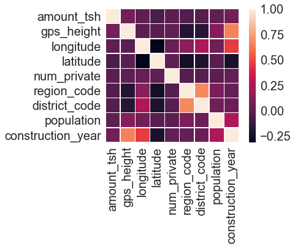

```python
corr = train.select_dtypes(include = ['float64', 'int64']).iloc[:,1:].corr()
sns.set(font_scale=2)
sns.heatmap(corr,  linewidths=0.3, square=True)
plt.rcParams["figure.figsize"] = (30,20)
plt.show()
```

## Checking Distribution of Target Variable in Training Data

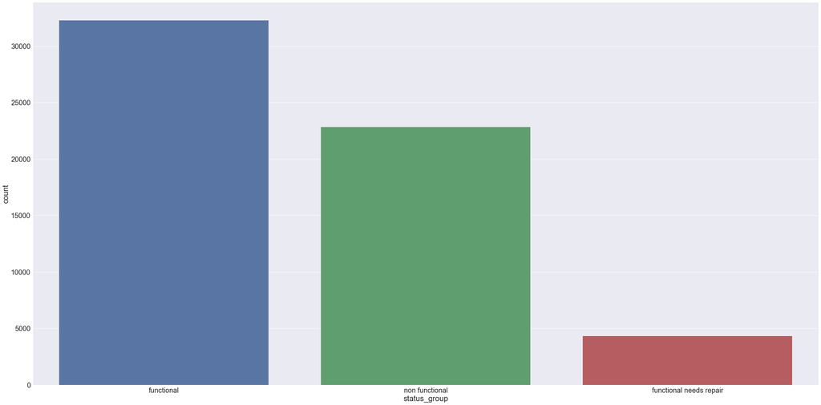

```python
sns.countplot('status_group', data = training_labels)
plt.rcParams["figure.figsize"] = (30,30)
plt.show()
```

## The distribution is unequal and we will have to decide on classification metrics for comparing models

- http://scikit-learn.org/stable/auto_examples/model_selection/plot_precision_recall.html#the-average-precision-score-in-multi-label-settings

# 1. Data Cleaning

## Inspecting Cardinality of Categorical Data

```python
cat_df = pd.DataFrame(columns=["Feature", "Cardinality","% Missings"])

total_cardinality = 0

i=0

for col in train.columns:
    if (train[col].dtype == np.object):
        cat_df.loc[i,"Feature"] = col
        cat_df.loc[i,"Cardinality"] = len(train[col].unique())
        total_cardinality += len(train[col].unique())
        pct_of_missing_values = float((len(train[col]) - train[col].count()) / len(train[col]))
        cat_df.loc[i,"% Missings"] = pct_of_missing_values*100
        i+=1

print("Total cardinality of categorical features:",total_cardinality)

display(cat_df)
```

```
Total cardinality of categorical features: 66181
```

|  | Feature | Cardinality | % Missings |
| --- | --- | --- | --- |
| 0 | status_group | 3 | 0 |
| 1 | date_recorded | 356 | 0 |
| 2 | funder | 1898 | 6.11953 |
| 3 | installer | 2146 | 6.1532 |
| 4 | wpt_name | 37400 | 0 |
| 5 | basin | 9 | 0 |
| 6 | subvillage | 19288 | 0.624579 |
| 7 | region | 21 | 0 |
| 8 | lga | 125 | 0 |
| 9 | ward | 2092 | 0 |
| 10 | public_meeting | 3 | 5.61279 |
| 11 | recorded_by | 1 | 0 |
| 12 | scheme_management | 13 | 6.52694 |
| 13 | scheme_name | 2697 | 47.4175 |
| 14 | permit | 3 | 5.14478 |
| 15 | extraction_type | 18 | 0 |
| 16 | extraction_type_group | 13 | 0 |
| 17 | extraction_type_class | 7 | 0 |
| 18 | management | 12 | 0 |
| 19 | management_group | 5 | 0 |
| 20 | payment | 7 | 0 |
| 21 | payment_type | 7 | 0 |
| 22 | water_quality | 8 | 0 |
| 23 | quality_group | 6 | 0 |
| 24 | quantity | 5 | 0 |
| 25 | quantity_group | 5 | 0 |
| 26 | source | 10 | 0 |
| 27 | source_type | 7 | 0 |
| 28 | source_class | 3 | 0 |
| 29 | waterpoint_type | 7 | 0 |
| 30 | waterpoint_type_group | 6 | 0 |

```python
#Combining Training and Testing Data for ease of imputations and feature engineering
combineddf=pd.concat([train,test],axis=0,ignore_index=True)
combineddf.head(5)
```

|  | amount_tsh | basin | construction_year | date_recorded | district_code | extraction_type | extraction_type_class | extraction_type_group | funder | gps_height | ... | source | source_class | source_type | status_group | subvillage | ward | water_quality | waterpoint_type | waterpoint_type_group | wpt_name |
| --- | --- | --- | --- | --- | --- | --- | --- | --- | --- | --- | --- | --- | --- | --- | --- | --- | --- | --- | --- | --- | --- |
| 0 | 6000.0 | Lake Nyasa | 1999 | 14-03-11 | 5 | gravity | gravity | gravity | Roman | 1390 | ... | spring | groundwater | spring | functional | Mnyusi B | Mundindi | soft | communal standpipe | communal standpipe | none |
| 1 | 0.0 | Lake Victoria | 2010 | 06-03-13 | 2 | gravity | gravity | gravity | Grumeti | 1399 | ... | rainwater harvesting | surface | rainwater harvesting | functional | Nyamara | Natta | soft | communal standpipe | communal standpipe | Zahanati |
| 2 | 25.0 | Pangani | 2009 | 25-02-13 | 4 | gravity | gravity | gravity | Lottery Club | 686 | ... | dam | surface | dam | functional | Majengo | Ngorika | soft | communal standpipe multiple | communal standpipe | Kwa Mahundi |
| 3 | 0.0 | Ruvuma / Southern Coast | 1986 | 28-01-13 | 63 | submersible | submersible | submersible | Unicef | 263 | ... | machine dbh | groundwater | borehole | non functional | Mahakamani | Nanyumbu | soft | communal standpipe multiple | communal standpipe | Zahanati Ya Nanyumbu |
| 4 | 0.0 | Lake Victoria | 0 | 13-07-11 | 1 | gravity | gravity | gravity | Action In A | 0 | ... | rainwater harvesting | surface | rainwater harvesting | functional | Kyanyamisa | Nyakasimbi | soft | communal standpipe | communal standpipe | Shuleni |

5 rows × 41 columns

## Dropping categories with too few or too many factor levels

```python
combineddf.drop(['wpt_name',    # too many levels
    'subvillage',  # too many levels; we have lat and long for location
    'ward',        # too many levels; we have lat and long for location
    'recorded_by', # constant
    'scheme_name', # too many levels
    'num_private', # irrelevant
    'region_code', # too many levels; we have lat and long for location
    'quantity_group', #same as quantity column
    'source_type',   #same as source but with fewer levels
    'waterpoint_type_group', #same as waterpoint
    'payment_type'],   #same as payment
              axis=1, inplace=True)

combineddf.shape
```

```
(74250, 30)
```

```python
combinedtemp= combineddf['construction_year'].replace(0,nan)
combinedtemp1=combinedtemp.dropna(how='all',axis=0)
combinedtemp1.median()
#We will use this to replace 0's in construction year in the combined df
```

```
2000.0
```

```python
combinedtemp2= combineddf['gps_height'].replace(0,nan)
combinedtemp3=combinedtemp2.dropna(how='all',axis=0)
combinedtemp3.median()
#We will use this to replace 0's in gps height in the combined df
```

```
1166.0
```

### Replacing Na's, Extracting Features and Converting Datatypes for better representation

```python
#Replace Na's with 0
combineddf['funder'].replace(nan,0, inplace= True)
combineddf['installer'].replace(nan,0, inplace= True)
combineddf['permit'].replace(nan,0, inplace= True)
combineddf['scheme_management'].replace(nan,0, inplace= True)

#contains True or False values
combineddf['public_meeting'].fillna(value=True, inplace=True)

#Replace 0's with arbitrary categories
combineddf['permit'].replace("0","TRUE", inplace= True) #corresponding to 0's almost entirely not pay to use - so let's consider as True
combineddf['public_meeting'].replace("0","TRUE", inplace= True)
combineddf['scheme_management'].replace(0, "Unknown", inplace=True)  #large number of Blanks - cannot fit this into None or Other group
combineddf['funder'].replace(0, "Other", inplace=True)
combineddf['installer'].replace(0, "Other", inplace=True)
combineddf['installer'].replace('-', "Other", inplace=True)
combineddf['construction_year'].replace(0, 2000, inplace=True) #median value for values aside from 0
combineddf['gps_height'].replace(0, 1166, inplace=True)        #median value for values aside from 0

combineddf['date_recorded'] = pd.to_datetime(combineddf['date_recorded'])   #converting date_recorded into number of days since first recorded date
combineddf['date_recorded'] = (combineddf['date_recorded'] - combineddf['date_recorded'].min()) / np.timedelta64(1, 'D')

#Type-conversion
combineddf['population']=combineddf['population'].astype('float64')  #we all float down here
combineddf['gps_height']=combineddf['gps_height'].astype('float64')
combineddf['construction_year']=combineddf['construction_year'].astype('float64')
combineddf['amount_tsh']=combineddf['amount_tsh'].astype('float64')
```

```python
display(combineddf)
```

|  | amount_tsh | basin | construction_year | date_recorded | district_code | extraction_type | extraction_type_class | extraction_type_group | funder | gps_height | ... | public_meeting | quality_group | quantity | region | scheme_management | source | source_class | status_group | water_quality | waterpoint_type |
| --- | --- | --- | --- | --- | --- | --- | --- | --- | --- | --- | --- | --- | --- | --- | --- | --- | --- | --- | --- | --- | --- |
| 0 | 6000.0 | Lake Nyasa | 1999.0 | 3640.0 | 5 | gravity | gravity | gravity | Roman | 1390.0 | ... | True | good | enough | Iringa | VWC | spring | groundwater | functional | soft | communal standpipe |
| 1 | 0.0 | Lake Victoria | 2010.0 | 4452.0 | 2 | gravity | gravity | gravity | Grumeti | 1399.0 | ... | True | good | insufficient | Mara | Other | rainwater harvesting | surface | functional | soft | communal standpipe |
| 2 | 25.0 | Pangani | 2009.0 | 4354.0 | 4 | gravity | gravity | gravity | Lottery Club | 686.0 | ... | True | good | enough | Manyara | VWC | dam | surface | functional | soft | communal standpipe multiple |
| 3 | 0.0 | Ruvuma / Southern Coast | 1986.0 | 4326.0 | 63 | submersible | submersible | submersible | Unicef | 263.0 | ... | True | good | dry | Mtwara | VWC | machine dbh | groundwater | non functional | soft | communal standpipe multiple |
| 4 | 0.0 | Lake Victoria | 2000.0 | 3761.0 | 1 | gravity | gravity | gravity | Action In A | 1166.0 | ... | True | good | seasonal | Kagera | Unknown | rainwater harvesting | surface | functional | soft | communal standpipe |
| 5 | 20.0 | Pangani | 2009.0 | 3639.0 | 8 | submersible | submersible | submersible | Mkinga Distric Coun | 1166.0 | ... | True | salty | enough | Tanga | VWC | other | unknown | functional | salty | communal standpipe multiple |
| 6 | 0.0 | Internal | 2000.0 | 3942.0 | 3 | swn 80 | handpump | swn 80 | Dwsp | 1166.0 | ... | True | good | enough | Shinyanga | VWC | machine dbh | groundwater | non functional | soft | hand pump |
| 7 | 0.0 | Lake Tanganyika | 2000.0 | 4186.0 | 3 | nira/tanira | handpump | nira/tanira | Rwssp | 1166.0 | ... | True | milky | enough | Shinyanga | Unknown | shallow well | groundwater | non functional | milky | hand pump |
| 8 | 0.0 | Lake Tanganyika | 2000.0 | 4003.0 | 6 | india mark ii | handpump | india mark ii | Wateraid | 1166.0 | ... | True | salty | seasonal | Tabora | VWC | machine dbh | groundwater | non functional | salty | hand pump |
| 9 | 0.0 | Lake Victoria | 2000.0 | 3634.0 | 1 | nira/tanira | handpump | nira/tanira | Isingiro Ho | 1166.0 | ... | True | good | enough | Kagera | Unknown | shallow well | groundwater | functional | soft | hand pump |
| 10 | 0.0 | Wami / Ruvu | 2011.0 | 3618.0 | 43 | submersible | submersible | submersible | Private | 62.0 | ... | True | salty | enough | Pwani | Private operator | machine dbh | groundwater | functional | salty | other |
| 11 | 200.0 | Lake Nyasa | 1987.0 | 4347.0 | 5 | swn 80 | handpump | swn 80 | Danida | 1062.0 | ... | True | good | insufficient | Ruvuma | WUG | shallow well | groundwater | functional | soft | hand pump |
| 12 | 0.0 | Internal | 2000.0 | 4220.0 | 2 | nira/tanira | handpump | nira/tanira | World Vision | 1166.0 | ... | True | good | enough | Shinyanga | WUG | shallow well | groundwater | functional | soft | hand pump |
| 13 | 0.0 | Pangani | 2009.0 | 4372.0 | 7 | gravity | gravity | gravity | Lawatefuka Water Supply | 1368.0 | ... | True | good | enough | Kilimanjaro | Water Board | spring | groundwater | functional | soft | communal standpipe |
| 14 | 0.0 | Internal | 2000.0 | 4226.0 | 6 | nira/tanira | handpump | nira/tanira | Biore | 1166.0 | ... | True | good | enough | Shinyanga | WUG | shallow well | groundwater | functional | soft | hand pump |
| 15 | 0.0 | Lake Tanganyika | 1991.0 | 3665.0 | 2 | swn 80 | handpump | swn 80 | Rudep | 1645.0 | ... | True | good | enough | Rukwa | VWC | machine dbh | groundwater | functional | soft | hand pump |
| 16 | 500.0 | Rufiji | 1978.0 | 3664.0 | 4 | gravity | gravity | gravity | Unicef | 1703.0 | ... | True | good | dry | Iringa | WUA | river | surface | non functional | soft | communal standpipe |
| 17 | 0.0 | Rufiji | 1978.0 | 3666.0 | 4 | gravity | gravity | gravity | Unicef | 1656.0 | ... | True | good | dry | Iringa | WUA | river | surface | non functional | soft | communal standpipe |
| 18 | 0.0 | Lake Victoria | 1999.0 | 3770.0 | 1 | other | other | other | Hesawa | 1162.0 | ... | True | milky | insufficient | Mwanza | Unknown | spring | groundwater | functional needs repair | milky | other |
| 19 | 500.0 | Lake Nyasa | 1992.0 | 3620.0 | 5 | gravity | gravity | gravity | Danida | 1763.0 | ... | True | good | enough | Iringa | VWC | spring | groundwater | functional | soft | communal standpipe |
| 20 | 200.0 | Lake Nyasa | 2008.0 | 3625.0 | 4 | gravity | gravity | gravity | Twe | 2216.0 | ... | True | good | enough | Iringa | VWC | spring | groundwater | functional | soft | communal standpipe |
| 21 | 0.0 | Lake Victoria | 2000.0 | 4573.0 | 1 | swn 80 | handpump | swn 80 | Dwsp | 1166.0 | ... | True | unknown | unknown | Shinyanga | WUG | shallow well | groundwater | functional | unknown | hand pump |
| 22 | 0.0 | Rufiji | 1978.0 | 3667.0 | 4 | gravity | gravity | gravity | Unicef | 1510.0 | ... | True | good | enough | Iringa | WUA | river | surface | functional needs repair | soft | communal standpipe |
| 23 | 500.0 | Pangani | 2011.0 | 4368.0 | 3 | gravity | gravity | gravity | Isf | 672.0 | ... | True | good | enough | Kilimanjaro | Water authority | river | surface | functional | soft | communal standpipe |
| 24 | 0.0 | Lake Tanganyika | 2009.0 | 4319.0 | 3 | gravity | gravity | gravity | African Development Bank | 1645.0 | ... | False | good | enough | Kigoma | VWC | spring | groundwater | functional | soft | improved spring |
| 25 | 0.0 | Pangani | 1974.0 | 4354.0 | 4 | gravity | gravity | gravity | Government Of Tanzania | 1273.0 | ... | True | good | enough | Kilimanjaro | VWC | spring | groundwater | functional needs repair | soft | communal standpipe |
| 26 | 500.0 | Ruvuma / Southern Coast | 2011.0 | 4314.0 | 23 | india mark ii | handpump | india mark ii | Sobodo | 200.0 | ... | False | good | enough | Lindi | VWC | machine dbh | groundwater | functional | soft | hand pump |
| 27 | 0.0 | Lake Victoria | 2000.0 | 3878.0 | 1 | nira/tanira | handpump | nira/tanira | Hesawa | 1166.0 | ... | True | good | enough | Kagera | Unknown | shallow well | groundwater | functional | soft | hand pump |
| 28 | 0.0 | Pangani | 2000.0 | 4421.0 | 1 | gravity | gravity | gravity | Government Of Tanzania | 1443.0 | ... | True | good | insufficient | Kilimanjaro | Company | spring | groundwater | non functional | soft | communal standpipe |
| 29 | 0.0 | Pangani | 2002.0 | 4373.0 | 7 | gravity | gravity | gravity | Lawatefuka Water Supply | 1256.0 | ... | True | good | enough | Kilimanjaro | Water Board | spring | groundwater | functional | soft | communal standpipe |
| ... | ... | ... | ... | ... | ... | ... | ... | ... | ... | ... | ... | ... | ... | ... | ... | ... | ... | ... | ... | ... | ... |
| 74220 | 0.0 | Ruvuma / Southern Coast | 2001.0 | 4325.0 | 3 | gravity | gravity | gravity | Dbfpe | 265.0 | ... | True | good | seasonal | Lindi | VWC | rainwater harvesting | surface | NaN | soft | communal standpipe |
| 74221 | 5.0 | Pangani | 2007.0 | 4386.0 | 4 | gravity | gravity | gravity | Ces (gmbh) | 1322.0 | ... | True | good | enough | Kilimanjaro | Water Board | river | surface | NaN | soft | communal standpipe |
| 74222 | 50.0 | Ruvuma / Southern Coast | 1997.0 | 4320.0 | 33 | gravity | gravity | gravity | Lga | 640.0 | ... | True | good | insufficient | Mtwara | Other | spring | groundwater | NaN | soft | communal standpipe |
| 74223 | 0.0 | Lake Nyasa | 2000.0 | 3630.0 | 4 | gravity | gravity | gravity | Other | 1166.0 | ... | True | good | enough | Mbeya | Parastatal | spring | groundwater | NaN | soft | communal standpipe |
| 74224 | 0.0 | Wami / Ruvu | 2008.0 | 3677.0 | 1 | swn 80 | handpump | swn 80 | Po | 574.0 | ... | True | good | insufficient | Morogoro | VWC | shallow well | groundwater | NaN | soft | hand pump |
| 74225 | 0.0 | Ruvuma / Southern Coast | 1978.0 | 4331.0 | 63 | india mark ii | handpump | india mark ii | Fin Water | 331.0 | ... | True | good | insufficient | Mtwara | VWC | machine dbh | groundwater | NaN | soft | hand pump |
| 74226 | 0.0 | Lake Tanganyika | 2000.0 | 4230.0 | 5 | nira/tanira | handpump | nira/tanira | World Vision | 1166.0 | ... | True | good | enough | Shinyanga | WUG | shallow well | groundwater | NaN | soft | hand pump |
| 74227 | 0.0 | Lake Victoria | 2000.0 | 3771.0 | 7 | nira/tanira | handpump | nira/tanira | Hesawa | 1166.0 | ... | True | good | enough | Mwanza | VWC | shallow well | groundwater | NaN | soft | hand pump |
| 74228 | 50.0 | Wami / Ruvu | 2000.0 | 3618.0 | 43 | other | other | other | Private | 78.0 | ... | False | salty | enough | Pwani | Private operator | machine dbh | groundwater | NaN | salty | other |
| 74229 | 0.0 | Ruvuma / Southern Coast | 2005.0 | 4358.0 | 3 | gravity | gravity | gravity | Government Of Tanzania | 836.0 | ... | True | good | enough | Ruvuma | VWC | spring | groundwater | NaN | soft | communal standpipe |
| 74230 | 0.0 | Pangani | 1996.0 | 4376.0 | 3 | gravity | gravity | gravity | Tcrs | 1651.0 | ... | True | good | insufficient | Kilimanjaro | Water authority | spring | groundwater | NaN | soft | communal standpipe |
| 74231 | 0.0 | Lake Victoria | 2000.0 | 4232.0 | 2 | nira/tanira | handpump | nira/tanira | Hesawa | 1166.0 | ... | True | salty | enough | Mwanza | VWC | shallow well | groundwater | NaN | salty | hand pump |
| 74232 | 0.0 | Pangani | 2001.0 | 4382.0 | 7 | submersible | submersible | submersible | Kkkt | 1393.0 | ... | True | fluoride | enough | Arusha | VWC | machine dbh | groundwater | NaN | fluoride abandoned | communal standpipe |
| 74233 | 1000.0 | Lake Nyasa | 2003.0 | 3690.0 | 3 | gravity | gravity | gravity | Kkkt | 1729.0 | ... | True | good | enough | Iringa | VWC | spring | groundwater | NaN | soft | communal standpipe |
| 74234 | 0.0 | Internal | 2000.0 | 3653.0 | 1 | gravity | gravity | gravity | Kirde | 1166.0 | ... | True | good | insufficient | Dodoma | VWC | spring | groundwater | NaN | soft | communal standpipe |
| 74235 | 0.0 | Lake Tanganyika | 2000.0 | 4323.0 | 3 | nira/tanira | handpump | nira/tanira | Rwssp | 1166.0 | ... | True | good | enough | Shinyanga | Unknown | shallow well | groundwater | NaN | soft | hand pump |
| 74236 | 0.0 | Rufiji | 2009.0 | 3644.0 | 4 | swn 80 | handpump | swn 80 | Amref | -7.0 | ... | True | good | enough | Pwani | VWC | shallow well | groundwater | NaN | soft | hand pump |
| 74237 | 500.0 | Lake Tanganyika | 2010.0 | 4573.0 | 2 | india mark ii | handpump | india mark ii | Tasaf | 1241.0 | ... | True | good | enough | Kigoma | Water authority | machine dbh | groundwater | NaN | soft | hand pump |
| 74238 | 3000.0 | Lake Nyasa | 1986.0 | 3874.0 | 3 | gravity | gravity | gravity | Kkkt | 2046.0 | ... | True | good | enough | Iringa | VWC | spring | groundwater | NaN | soft | communal standpipe |
| 74239 | 0.0 | Pangani | 2005.0 | 3874.0 | 2 | gravity | gravity | gravity | Devon Aid Korogwe | 347.0 | ... | True | good | insufficient | Tanga | Other | spring | groundwater | NaN | soft | communal standpipe |
| 74240 | 0.0 | Lake Nyasa | 2009.0 | 4353.0 | 2 | gravity | gravity | gravity | Villagers | 1291.0 | ... | True | good | enough | Ruvuma | VWC | river | surface | NaN | soft | communal standpipe |
| 74241 | 0.0 | Lake Victoria | 2000.0 | 4232.0 | 1 | swn 80 | handpump | swn 80 | Dwsp | 1166.0 | ... | True | good | enough | Shinyanga | WUG | shallow well | groundwater | NaN | soft | hand pump |
| 74242 | 600.0 | Lake Tanganyika | 2009.0 | 4325.0 | 3 | gravity | gravity | gravity | Isf | 808.0 | ... | True | good | enough | Kigoma | WUG | river | surface | NaN | soft | communal standpipe multiple |
| 74243 | 0.0 | Lake Tanganyika | 1995.0 | 4390.0 | 2 | other | other | other | Oxfarm | 1641.0 | ... | True | good | enough | Kigoma | Water authority | spring | groundwater | NaN | soft | other |
| 74244 | 0.0 | Lake Victoria | 2000.0 | 4125.0 | 2 | nira/tanira | handpump | nira/tanira | Netherlands | 1166.0 | ... | True | good | enough | Shinyanga | WUG | shallow well | groundwater | NaN | soft | hand pump |
| 74245 | 0.0 | Wami / Ruvu | 1988.0 | 3622.0 | 1 | mono | motorpump | mono | Danida | 34.0 | ... | True | good | enough | Pwani | VWC | river | surface | NaN | soft | communal standpipe |
| 74246 | 1000.0 | Pangani | 1994.0 | 3647.0 | 7 | nira/tanira | handpump | nira/tanira | Hiap | 1166.0 | ... | True | salty | insufficient | Tanga | VWC | shallow well | groundwater | NaN | salty | hand pump |
| 74247 | 0.0 | Internal | 2010.0 | 4391.0 | 2 | gravity | gravity | gravity | Other | 1476.0 | ... | True | good | insufficient | Singida | VWC | dam | surface | NaN | soft | communal standpipe |
| 74248 | 0.0 | Lake Nyasa | 2009.0 | 4347.0 | 2 | gravity | gravity | gravity | Germany | 998.0 | ... | True | good | insufficient | Ruvuma | VWC | river | surface | NaN | soft | communal standpipe |
| 74249 | 0.0 | Lake Nyasa | 2008.0 | 4342.0 | 3 | gravity | gravity | gravity | Government Of Tanzania | 481.0 | ... | True | good | dry | Ruvuma | VWC | spring | groundwater | NaN | soft | communal standpipe |

74250 rows × 30 columns

#### Dropping similar columns and combining similar features

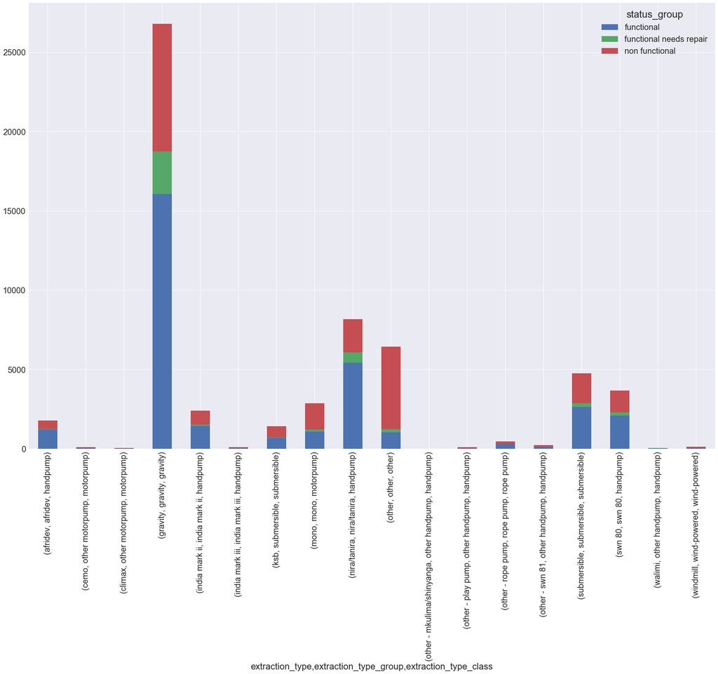

```python
cross_tab_extraction = pd.crosstab([combineddf.extraction_type, combineddf.extraction_type_group, combineddf.extraction_type_class], combineddf.status_group)
cross_tab_extraction.plot(kind='bar', stacked=True)
```

```python
display(cross_tab_extraction)
```

| extraction_type | extraction_type_group | status_group extraction_type_class | functional | functional needs repair | non functional |
| --- | --- | --- | --- | --- | --- |
| afridev | afridev | handpump | 1200 | 42 | 528 |
| cemo | other motorpump | motorpump | 45 | 9 | 36 |
| climax | other motorpump | motorpump | 8 | 0 | 24 |
| gravity | gravity | gravity | 16048 | 2701 | 8031 |
| india mark ii | india mark ii | handpump | 1448 | 79 | 873 |
| india mark iii | india mark iii | handpump | 44 | 1 | 53 |
| ksb | submersible | submersible | 703 | 26 | 686 |
| mono | mono | motorpump | 1082 | 129 | 1654 |
| nira/tanira | nira/tanira | handpump | 5421 | 641 | 2092 |
| other | other | other | 1029 | 206 | 5195 |
| other - mkulima/shinyanga | other handpump | handpump | 0 | 0 | 2 |
| other - play pump | other handpump | handpump | 29 | 1 | 55 |
| other - rope pump | rope pump | rope pump | 293 | 17 | 141 |
| other - swn 81 | other handpump | handpump | 120 | 7 | 102 |
| submersible | submersible | submersible | 2626 | 227 | 1911 |
| swn 80 | swn 80 | handpump | 2090 | 212 | 1368 |
| walimi | other handpump | handpump | 23 | 12 | 13 |
| windmill | wind-powered | wind-powered | 50 | 7 | 60 |

```python
combineddf.groupby(['extraction_type_class','extraction_type_group'])['extraction_type'].value_counts()
```

```
extraction_type_class  extraction_type_group  extraction_type
gravity                gravity                gravity                      33263
handpump               afridev                afridev                       2208
                       india mark ii          india mark ii                 3029
                       india mark iii         india mark iii                 135
                       nira/tanira            nira/tanira                  10205
                       other handpump         other - swn 81                 284
                                              other - play pump              101
                                              walimi                          60
                                              other - mkulima/shinyanga        2
                       swn 80                 swn 80                        4588
motorpump              mono                   mono                          3628
                       other motorpump        cemo                           108
                                              climax                          41
other                  other                  other                         8102
rope pump              rope pump              other - rope pump              572
submersible            submersible            submersible                   5982
                                              ksb                           1790
wind-powered           wind-powered           windmill                       152
Name: extraction_type, dtype: int64
```

```python
#Define function to replace repeating values under common levels within extracting type - make extraction type group obsolete
def clean_values(combineddf, col, values_dict):
    for k, v in values_dict.items():
        combineddf.loc[combineddf[col] == k, col] = v

#Define key-value pairs for replacing
clean_values(combineddf, 'extraction_type',
    {
        'india mark ii'             : 'india',
        'india mark iii'            : 'india',
        'other - swn 81'            : 'swn',
        'swn 80'                    : 'swn',
        'other - play pump'         : 'other handpump',
        'walimi'                    : 'other handpump',
        'other - mkulima/shinyanga' : 'other handpump',
        'cemo'                      : 'other motorpump',
        'climax'                    : 'other motorpump',
    }
)


#Drop 'extraction_type_group'
combineddf.drop(['extraction_type_group'],axis=1, inplace=True)
combineddf.shape
```

```
(74250, 29)
```

```python
combineddf.groupby(['extraction_type_class'])['extraction_type'].value_counts()
```

```
extraction_type_class  extraction_type
gravity                gravity              33263
handpump               nira/tanira          10205
                       swn                   4872
                       india                 3164
                       afridev               2208
                       other handpump         163
motorpump              mono                  3628
                       other motorpump        149
other                  other                 8102
rope pump              other - rope pump      572
submersible            submersible           5982
                       ksb                   1790
wind-powered           windmill               152
Name: extraction_type, dtype: int64
```

```python
combineddf.isnull().sum()
```

```
amount_tsh                   0
basin                        0
construction_year            0
date_recorded                0
district_code                0
extraction_type              0
extraction_type_class        0
funder                       0
gps_height                   0
id                           0
installer                    0
latitude                     0
lga                          0
longitude                    0
management                   0
management_group             0
payment                      0
permit                       0
population                   0
public_meeting               0
quality_group                0
quantity                     0
region                       0
scheme_management            0
source                       0
source_class                 0
status_group             14850
water_quality                0
waterpoint_type              0
dtype: int64
```

```python
#Latitude and Longitude to cartesian coordinates
# Assuming Earth as sphere not ellipsoid
def cartesian_x(lat,lon):
    lat=radians(lat)
    lon=radians(lon)
    R=6371.0
    x = R * cos(lat) * cos(lon)
    return x
def cartesian_y(lat,lon):
    lat=radians(lat)
    lon=radians(lon)
    R=6371.0
    y = R * cos(lat) * sin(lon)
    return y

# extracting cartesian x,y cordinates form latitude and longitude
combineddf['x1']=[cartesian_x(i,j) for i,j in zip(combineddf['latitude'],combineddf['longitude'])]
combineddf['y1']=[cartesian_y(i,j) for i,j in zip(combineddf['latitude'],combineddf['longitude'])]

#Manhattan distance as a new feature
#combineddf['Manhattan_dist'] =(combineddf['x1']).abs() +(combineddf['y1']).abs()
```

```python
combineddf.drop(['latitude',
    'longitude'
    #,'x1',
    #'y1'
                ], axis=1, inplace=True)
```

```python
display(combineddf['funder'].describe())
```

```
count                      74250
unique                      2141
top       Government Of Tanzania
freq                       11299
Name: funder, dtype: object
```

#### Tried to represent Funder and Installer categories as a function of their frequency, but it was not considered as an important feature by multiple models

#### Hence, reverted to a different representation method

```python
#def freq_map(x):
#    try:
#        return freq[x]
#    except KeyError:
#        return 0

#freq = combineddf['funder'].value_counts().to_dict()
#combineddf['funder_freq'] = combineddf['funder'].apply(freq_map)

#display(combineddf['funder_freq'].describe())
```

```python
#histogram of funder_frequency
#sns.distplot(combineddf['funder_freq'], hist=True, fit=norm)
```

```python
#doing box-cox to normalize
#combineddf['funder_freq_BC'] = boxcox(combineddf['funder_freq'] + 1)[0]

#sns.distplot(combineddf['funder_freq_BC'], hist = True, fit=norm)
```

```python
#moving on to 'installer' which has similar # of levels
```

```python
#display(combineddf['installer'].describe())
```

```python
#doing similar feature engineering for Installer
#def freq_map(x):
#    try:
#        return freq[x]
#    except KeyError:
#        return 0

#freq = combineddf['installer'].value_counts().to_dict()
#combineddf['installer_freq'] = combineddf['installer'].apply(freq_map)

#display(combineddf['installer_freq'].describe())

#combineddf['installer_freq_BC'] = boxcox(combineddf['installer_freq'] + 1)[0]
```

```python
#dropping duplicated features
#combineddf.drop(['installer_freq',
#    'installer',
#    'funder_freq',
#    'funder'],
#    axis=1, inplace=True)
```

```python
combineddf.select_dtypes(['object'])
```

|  | basin | extraction_type | extraction_type_class | funder | installer | lga | management | management_group | payment | permit | quality_group | quantity | region | scheme_management | source | source_class | status_group | water_quality | waterpoint_type |
| --- | --- | --- | --- | --- | --- | --- | --- | --- | --- | --- | --- | --- | --- | --- | --- | --- | --- | --- | --- |
| 0 | Lake Nyasa | gravity | gravity | Roman | Roman | Ludewa | vwc | user-group | pay annually | False | good | enough | Iringa | VWC | spring | groundwater | functional | soft | communal standpipe |
| 1 | Lake Victoria | gravity | gravity | Grumeti | GRUMETI | Serengeti | wug | user-group | never pay | True | good | insufficient | Mara | Other | rainwater harvesting | surface | functional | soft | communal standpipe |
| 2 | Pangani | gravity | gravity | Lottery Club | World vision | Simanjiro | vwc | user-group | pay per bucket | True | good | enough | Manyara | VWC | dam | surface | functional | soft | communal standpipe multiple |
| 3 | Ruvuma / Southern Coast | submersible | submersible | Unicef | UNICEF | Nanyumbu | vwc | user-group | never pay | True | good | dry | Mtwara | VWC | machine dbh | groundwater | non functional | soft | communal standpipe multiple |
| 4 | Lake Victoria | gravity | gravity | Action In A | Artisan | Karagwe | other | other | never pay | True | good | seasonal | Kagera | Unknown | rainwater harvesting | surface | functional | soft | communal standpipe |
| 5 | Pangani | submersible | submersible | Mkinga Distric Coun | DWE | Mkinga | vwc | user-group | pay per bucket | True | salty | enough | Tanga | VWC | other | unknown | functional | salty | communal standpipe multiple |
| 6 | Internal | swn | handpump | Dwsp | DWSP | Shinyanga Rural | vwc | user-group | never pay | True | good | enough | Shinyanga | VWC | machine dbh | groundwater | non functional | soft | hand pump |
| 7 | Lake Tanganyika | nira/tanira | handpump | Rwssp | DWE | Kahama | wug | user-group | unknown | True | milky | enough | Shinyanga | Unknown | shallow well | groundwater | non functional | milky | hand pump |
| 8 | Lake Tanganyika | india | handpump | Wateraid | Water Aid | Tabora Urban | vwc | user-group | never pay | True | salty | seasonal | Tabora | VWC | machine dbh | groundwater | non functional | salty | hand pump |
| 9 | Lake Victoria | nira/tanira | handpump | Isingiro Ho | Artisan | Karagwe | vwc | user-group | never pay | True | good | enough | Kagera | Unknown | shallow well | groundwater | functional | soft | hand pump |
| 10 | Wami / Ruvu | submersible | submersible | Private | Private | Mkuranga | private operator | commercial | never pay | False | salty | enough | Pwani | Private operator | machine dbh | groundwater | functional | salty | other |
| 11 | Lake Nyasa | swn | handpump | Danida | DANIDA | Namtumbo | wug | user-group | pay when scheme fails | False | good | insufficient | Ruvuma | WUG | shallow well | groundwater | functional | soft | hand pump |
| 12 | Internal | nira/tanira | handpump | World Vision | World vision | Maswa | wug | user-group | other | False | good | enough | Shinyanga | WUG | shallow well | groundwater | functional | soft | hand pump |
| 13 | Pangani | gravity | gravity | Lawatefuka Water Supply | Lawatefuka water sup | Siha | water board | user-group | pay monthly | True | good | enough | Kilimanjaro | Water Board | spring | groundwater | functional | soft | communal standpipe |
| 14 | Internal | nira/tanira | handpump | Biore | WEDECO | Meatu | wug | user-group | never pay | True | good | enough | Shinyanga | WUG | shallow well | groundwater | functional | soft | hand pump |
| 15 | Lake Tanganyika | swn | handpump | Rudep | DWE | Sumbawanga Rural | vwc | user-group | never pay | False | good | enough | Rukwa | VWC | machine dbh | groundwater | functional | soft | hand pump |
| 16 | Rufiji | gravity | gravity | Unicef | DWE | Njombe | wua | user-group | pay monthly | True | good | dry | Iringa | WUA | river | surface | non functional | soft | communal standpipe |
| 17 | Rufiji | gravity | gravity | Unicef | DWE | Njombe | wua | user-group | pay when scheme fails | True | good | dry | Iringa | WUA | river | surface | non functional | soft | communal standpipe |
| 18 | Lake Victoria | other | other | Hesawa | DWE | Ukerewe | vwc | user-group | never pay | True | milky | insufficient | Mwanza | Unknown | spring | groundwater | functional needs repair | milky | other |
| 19 | Lake Nyasa | gravity | gravity | Danida | Danid | Ludewa | vwc | user-group | pay annually | True | good | enough | Iringa | VWC | spring | groundwater | functional | soft | communal standpipe |
| 20 | Lake Nyasa | gravity | gravity | Twe | TWE | Njombe | vwc | user-group | pay monthly | False | good | enough | Iringa | VWC | spring | groundwater | functional | soft | communal standpipe |
| 21 | Lake Victoria | swn | handpump | Dwsp | DWE | Bariadi | wug | user-group | unknown | False | unknown | unknown | Shinyanga | WUG | shallow well | groundwater | functional | unknown | hand pump |
| 22 | Rufiji | gravity | gravity | Unicef | DWE | Njombe | wua | user-group | never pay | True | good | enough | Iringa | WUA | river | surface | functional needs repair | soft | communal standpipe |
| 23 | Pangani | gravity | gravity | Isf | ISF | Same | vwc | user-group | pay monthly | True | good | enough | Kilimanjaro | Water authority | river | surface | functional | soft | communal standpipe |
| 24 | Lake Tanganyika | gravity | gravity | African Development Bank | DWE | Kigoma Rural | vwc | user-group | unknown | True | good | enough | Kigoma | VWC | spring | groundwater | functional | soft | improved spring |
| 25 | Pangani | gravity | gravity | Government Of Tanzania | DWE | Moshi Rural | vwc | user-group | unknown | True | good | enough | Kilimanjaro | VWC | spring | groundwater | functional needs repair | soft | communal standpipe |
| 26 | Ruvuma / Southern Coast | india | handpump | Sobodo | Kilolo Star | Lindi Rural | vwc | user-group | pay monthly | False | good | enough | Lindi | VWC | machine dbh | groundwater | functional | soft | hand pump |
| 27 | Lake Victoria | nira/tanira | handpump | Hesawa | DWE | Karagwe | vwc | user-group | never pay | True | good | enough | Kagera | Unknown | shallow well | groundwater | functional | soft | hand pump |
| 28 | Pangani | gravity | gravity | Government Of Tanzania | District council | Rombo | company | commercial | pay monthly | True | good | insufficient | Kilimanjaro | Company | spring | groundwater | non functional | soft | communal standpipe |
| 29 | Pangani | gravity | gravity | Lawatefuka Water Supply | Lawatefuka water sup | Siha | water board | user-group | pay monthly | True | good | enough | Kilimanjaro | Water Board | spring | groundwater | functional | soft | communal standpipe |
| ... | ... | ... | ... | ... | ... | ... | ... | ... | ... | ... | ... | ... | ... | ... | ... | ... | ... | ... | ... |
| 74220 | Ruvuma / Southern Coast | gravity | gravity | Dbfpe | DBFPE | Nachingwea | vwc | user-group | never pay | False | good | seasonal | Lindi | VWC | rainwater harvesting | surface | NaN | soft | communal standpipe |
| 74221 | Pangani | gravity | gravity | Ces (gmbh) | DWE | Moshi Rural | water board | user-group | pay per bucket | True | good | enough | Kilimanjaro | Water Board | river | surface | NaN | soft | communal standpipe |
| 74222 | Ruvuma / Southern Coast | gravity | gravity | Lga | LGA | Newala | other | other | pay per bucket | False | good | insufficient | Mtwara | Other | spring | groundwater | NaN | soft | communal standpipe |
| 74223 | Lake Nyasa | gravity | gravity | Other | Other | Rungwe | parastatal | parastatal | unknown | 0 | good | enough | Mbeya | Parastatal | spring | groundwater | NaN | soft | communal standpipe |
| 74224 | Wami / Ruvu | swn | handpump | Po | Po | Kilosa | vwc | user-group | never pay | True | good | insufficient | Morogoro | VWC | shallow well | groundwater | NaN | soft | hand pump |
| 74225 | Ruvuma / Southern Coast | india | handpump | Fin Water | FIN WATER | Nanyumbu | vwc | user-group | never pay | True | good | insufficient | Mtwara | VWC | machine dbh | groundwater | NaN | soft | hand pump |
| 74226 | Lake Tanganyika | nira/tanira | handpump | World Vision | World vision | Bukombe | wug | user-group | unknown | True | good | enough | Shinyanga | WUG | shallow well | groundwater | NaN | soft | hand pump |
| 74227 | Lake Victoria | nira/tanira | handpump | Hesawa | HESAWA | Sengerema | vwc | user-group | pay annually | True | good | enough | Mwanza | VWC | shallow well | groundwater | NaN | soft | hand pump |
| 74228 | Wami / Ruvu | other | other | Private | Private | Mkuranga | private operator | commercial | pay per bucket | False | salty | enough | Pwani | Private operator | machine dbh | groundwater | NaN | salty | other |
| 74229 | Ruvuma / Southern Coast | gravity | gravity | Government Of Tanzania | Government | Mbinga | vwc | user-group | unknown | True | good | enough | Ruvuma | VWC | spring | groundwater | NaN | soft | communal standpipe |
| 74230 | Pangani | gravity | gravity | Tcrs | TCRS | Same | vwc | user-group | never pay | True | good | insufficient | Kilimanjaro | Water authority | spring | groundwater | NaN | soft | communal standpipe |
| 74231 | Lake Victoria | nira/tanira | handpump | Hesawa | DWE | Magu | vwc | user-group | never pay | True | salty | enough | Mwanza | VWC | shallow well | groundwater | NaN | salty | hand pump |
| 74232 | Pangani | submersible | submersible | Kkkt | KKKT | Meru | vwc | user-group | unknown | False | fluoride | enough | Arusha | VWC | machine dbh | groundwater | NaN | fluoride abandoned | communal standpipe |
| 74233 | Lake Nyasa | gravity | gravity | Kkkt | Commu | Makete | vwc | user-group | pay annually | False | good | enough | Iringa | VWC | spring | groundwater | NaN | soft | communal standpipe |
| 74234 | Internal | gravity | gravity | Kirde | DWE | Kondoa | vwc | user-group | pay monthly | False | good | insufficient | Dodoma | VWC | spring | groundwater | NaN | soft | communal standpipe |
| 74235 | Lake Tanganyika | nira/tanira | handpump | Rwssp | DWE | Kahama | wug | user-group | unknown | True | good | enough | Shinyanga | Unknown | shallow well | groundwater | NaN | soft | hand pump |
| 74236 | Rufiji | swn | handpump | Amref | AMREF | Mkuranga | vwc | user-group | never pay | False | good | enough | Pwani | VWC | shallow well | groundwater | NaN | soft | hand pump |
| 74237 | Lake Tanganyika | india | handpump | Tasaf | TASAF | Kasulu | vwc | user-group | pay annually | False | good | enough | Kigoma | Water authority | machine dbh | groundwater | NaN | soft | hand pump |
| 74238 | Lake Nyasa | gravity | gravity | Kkkt | Commu | Makete | vwc | user-group | pay annually | False | good | enough | Iringa | VWC | spring | groundwater | NaN | soft | communal standpipe |
| 74239 | Pangani | gravity | gravity | Devon Aid Korogwe | Local technician | Korogwe | other | other | never pay | False | good | insufficient | Tanga | Other | spring | groundwater | NaN | soft | communal standpipe |
| 74240 | Lake Nyasa | gravity | gravity | Villagers | Villagers | Songea Rural | vwc | user-group | never pay | True | good | enough | Ruvuma | VWC | river | surface | NaN | soft | communal standpipe |
| 74241 | Lake Victoria | swn | handpump | Dwsp | DWE | Bariadi | wug | user-group | unknown | False | good | enough | Shinyanga | WUG | shallow well | groundwater | NaN | soft | hand pump |
| 74242 | Lake Tanganyika | gravity | gravity | Isf | DWE | Kigoma Rural | vwc | user-group | pay monthly | True | good | enough | Kigoma | WUG | river | surface | NaN | soft | communal standpipe multiple |
| 74243 | Lake Tanganyika | other | other | Oxfarm | OXFARM | Kigoma Rural | vwc | user-group | never pay | False | good | enough | Kigoma | Water authority | spring | groundwater | NaN | soft | other |
| 74244 | Lake Victoria | nira/tanira | handpump | Netherlands | DWE | Maswa | wug | user-group | other | False | good | enough | Shinyanga | WUG | shallow well | groundwater | NaN | soft | hand pump |
| 74245 | Wami / Ruvu | mono | motorpump | Danida | Da | Bagamoyo | vwc | user-group | never pay | True | good | enough | Pwani | VWC | river | surface | NaN | soft | communal standpipe |
| 74246 | Pangani | nira/tanira | handpump | Hiap | HIAP | Kilindi | vwc | user-group | pay annually | False | salty | insufficient | Tanga | VWC | shallow well | groundwater | NaN | salty | hand pump |
| 74247 | Internal | gravity | gravity | Other | Other | Singida Rural | vwc | user-group | never pay | 0 | good | insufficient | Singida | VWC | dam | surface | NaN | soft | communal standpipe |
| 74248 | Lake Nyasa | gravity | gravity | Germany | DWE | Songea Rural | vwc | user-group | never pay | True | good | insufficient | Ruvuma | VWC | river | surface | NaN | soft | communal standpipe |
| 74249 | Lake Nyasa | gravity | gravity | Government Of Tanzania | Government | Mbinga | vwc | user-group | never pay | True | good | dry | Ruvuma | VWC | spring | groundwater | NaN | soft | communal standpipe |

74250 rows × 19 columns

```python
#Listing Categorical columns for label encoding
cat_cols=combineddf.select_dtypes(include=['object']).columns.values.tolist()
cat_cols
```

```
['basin',
 'extraction_type',
 'extraction_type_class',
 'funder',
 'installer',
 'lga',
 'management',
 'management_group',
 'payment',
 'permit',
 'quality_group',
 'quantity',
 'region',
 'scheme_management',
 'source',
 'source_class',
 'status_group',
 'water_quality',
 'waterpoint_type']
```

### Treating Categorical and Numerical Features

```python
#Listing numerical columns for scaling
num_cols=combineddf.select_dtypes(include=['int64', 'float64']).columns.values.tolist()
num_cols
```

```
['amount_tsh',
 'construction_year',
 'date_recorded',
 'district_code',
 'gps_height',
 'id',
 'population',
 'x1',
 'y1']
```

```python
#Listing Categorical columns for label encoding
cols=('basin',
 'extraction_type',
 'extraction_type_class',
 'lga',
 'management',
 'management_group',
 'payment',
 'permit',
 'quality_group',
 'quantity',
 'region',
 'scheme_management',
 'source',
 'source_class',
 'water_quality',
 'waterpoint_type',
 'public_meeting',
 'funder',
 'installer')  #need to encode funder and installer to pass through models

# Applying Label Encoding
for c in cols:
    lbl = LabelEncoder()
    lbl.fit(list(combineddf[c].values))
    combineddf[c] = lbl.transform(list(combineddf[c].values))

###########################
#funder and installer had too many levels; going back to format them as function of frequency
###########################
combineddf.shape
```

```
(74250, 29)
```

```python
combineddf.dtypes
```

```
amount_tsh               float64
basin                      int64
construction_year        float64
date_recorded            float64
district_code              int64
extraction_type            int64
extraction_type_class      int64
funder                     int64
gps_height               float64
id                         int64
installer                  int64
lga                        int64
management                 int64
management_group           int64
payment                    int64
permit                     int64
population               float64
public_meeting             int64
quality_group              int64
quantity                   int64
region                     int64
scheme_management          int64
source                     int64
source_class               int64
status_group              object
water_quality              int64
waterpoint_type            int64
x1                       float64
y1                       float64
dtype: object
```

```python
# Scaling numeric features
scaler = StandardScaler()
numeric_features = combineddf.select_dtypes(include=np.float64)

scaler.fit(numeric_features)
combineddf[numeric_features.columns] = scaler.transform(combineddf[numeric_features.columns])

display(combineddf[numeric_features.columns].head())
```

|  | amount_tsh | construction_year | date_recorded | gps_height | population | x1 | y1 |
| --- | --- | --- | --- | --- | --- | --- | --- |
| 0 | 1.954529 | 0.102017 | -1.158258 | 0.641710 | -0.152310 | -0.166716 | -0.180223 |
| 1 | -0.109637 | 1.186609 | 1.257651 | 0.659671 | 0.210683 | 0.342934 | -0.051832 |
| 2 | -0.101036 | 1.088010 | 0.966076 | -0.763253 | 0.147000 | -0.740788 | 1.003381 |
| 3 | -0.109637 | -1.179773 | 0.882769 | -1.607428 | -0.260572 | -1.621649 | 1.106209 |
| 4 | -0.109637 | 0.200617 | -0.798252 | 0.194676 | -0.383692 | 1.588009 | -1.499332 |

```python
#Encoding status_group of train to pass it through our models
y = training_labels.status_group
LEncoder = LabelEncoder()
LEncoder.fit(y)
labels = LEncoder.transform(y)
print(LEncoder.classes_)
```

```
['functional' 'functional needs repair' 'non functional']
```

```python
display(labels)
```

```
array([0, 0, 2, ..., 0, 0, 0], dtype=int64)
```

#### Preparing Training, Validation and Test Data for Modeling

```python
x = combineddf[:train.shape[0]]
test_data = combineddf[train.shape[0]:]
```

```python
x.to_csv("pythonoutputtrain.csv")
test_data.to_csv("pythonoutputtest.csv")
```

```python
x.drop(['id'],axis=1, inplace=True)
x.drop(['status_group'],axis=1, inplace=True)
```

```python
test_data.drop(['id'],axis=1, inplace=True)
```

```python
temp_forid = combineddf[train.shape[0]:]
test_ids= temp_forid.id
```

```python
# Split training and validation data
x, labels = shuffle(x, labels, random_state= 10)
X_train, X_valid, y_train, y_valid = train_test_split(x, labels, train_size=0.8, random_state=10)
```

# 2. Building Models with prepared data

## Base Random Forest Model

```python
RF_model = RandomForestClassifier(n_estimators=1000)
RF_model.fit(X_train, y_train)
y_pred = RF_model.predict(X_valid)
```

```python
#Accuracy on validation data
acc=accuracy_score(y_valid, y_pred)
fscore = fbeta_score(y_valid, y_pred, average='weighted', beta=0.5)
print('RF Accuracy:', acc)
print('RF Fbeta score:', fscore)

#this is my base model - score was ~80.1 with this on the leaderboard.Not going with this for final submission unless I do an ensemble; used it to infer feature importances
#manhattan distance has lower importance than latitude longitude (based on past trials)
#but it's represented better, so will keep manhattan distance as is; plus CatBoost performs better with this feature than lat and long

#Finally decided to remove Manhattan distance and just keep the cartesian coordinates, because catboost did not perform well
```

```
RF Accuracy: 0.8058922558922559
RF Fbeta score: 0.799621972352458
```

```
Index(['x1', 'y1', 'quantity', 'date_recorded', 'gps_height',
       'waterpoint_type', 'construction_year', 'population', 'funder',
       'extraction_type_class'],
      dtype='object')
```

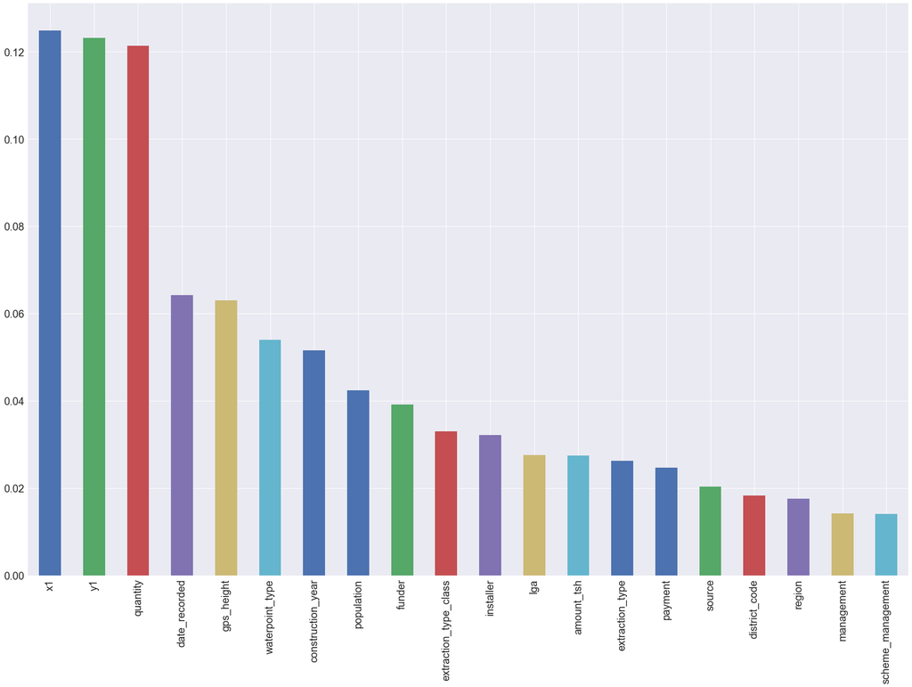

```python
features = RF_model.feature_importances_
imp_features = np.argsort(features)[::-1]
k = 20
print(x[:train.shape[0]].columns[imp_features[:10]])
series_imp_features = pd.Series(features[imp_features[:k]], x[:train.shape[0]].columns[imp_features[:k]])
series_imp_features.plot(kind='bar')
```